# Exposure to Tropical Cyclones and Wildfire Smoke PM2.5 Among Incarcerated People in the United States

**Biostatistician:** Bethany Akinola and Jordyn Begay

**Principal Investigator:** Robbie Parks, PhD

*July 21, 2026*

# Background and Motivation

There are critical knowledge gaps surrounding the availability of publicly usable data to create and inform policies targeting the mitigation of climate-related health risks of incarcerated people in the United States. Wildfire smoke has increasingly becoming public health concern, leading to adverse health outcomes such as respiratory infections and negative cardiovascular effects in the case of wildfire smoke. Tropical cyclones are also an emerging health risk as they may lead to water-related deaths or exposure to infectious disease. Incarcerated populations are particularly vulnerable to these climate-related risks because they lack agency to reduce the amount of exposure they experience. The goal of this project is to quantify exposure of incarcerated people to these two climate-related extremes by using a statistical framework created from a previous study on hazardous heat effects on incarcerated people in the United States.

# Data Preparation

# Descriptive Statistics

## Facility Demographics

**Table 1: Characteristics of Represented US Carceral Facilities**

| **Characteristic** | **N = 4,078**<sup>1</sup> |
| --- | --- |
| Facility Region |  |
| North Central | 1,015 (25%) |
| Northeast | 437 (11%) |
| South | 1,951 (48%) |
| West | 675 (17%) |
| Type of Facility |  |
| County | 2,142 (53%) |
| Federal | 232 (5.7%) |
| Local | 73 (1.8%) |
| Multi | 23 (0.6%) |
| Not Available | 2 (<0.1%) |
| State | 1,606 (39%) |
| Facility Population | 200 (60, 664) |

<sup>1</sup> n (%); Median (Q1, Q3)

There are 4,078 U.S. carceral facilities represented in the datasets. Almost half (48%) of these facilities exist in the southern region, specifically in Texas, Florida, and Georgia. County-level facilities make up the highest percentage (53%) of the 4,078 carceral facilities, followed by those on the state-level (39%), with the median population of all carceral facilities being 200 incarcerated people.

## Days of Exposure

### Tropical Cyclones and Hurricanes

**Table 2a: Number of Facility Days Above Windspeed (m/s) Threshold for Tropical Cyclones and Hurricanes**

| **Characteristic** | **Overall (18+)**<sup>1</sup> | **Tropical Cyclones (18-33)** N = 6,343<sup>1</sup> | **Hurricanes (33+)** N = 505<sup>1</sup> |
| --- | --- | --- | --- |
| Facility Region |  |  |  |
| North Central | 173 (2.5%) | 173 (2.7%) | 0 (0%) |
| Northeast | 661 (9.7%) | 659 (10%) | 2 (0.4%) |
| South | 6,014 (88%) | 5,511 (87%) | 503 (100%) |
| West | 0 (0%) | 0 (0%) | 0 (0%) |
| Type of Facility |  |  |  |
| County | 2,906 (42%) | 2,682 (42%) | 224 (44%) |
| Federal | 441 (6.4%) | 404 (6.4%) | 37 (7.3%) |
| Local | 164 (2.4%) | 163 (2.6%) | 1 (0.2%) |
| Multi | 28 (0.4%) | 28 (0.4%) | 0 (0%) |
| State | 3,309 (48%) | 3,066 (48%) | 243 (48%) |

<sup>1</sup> n (%)

Overall, the majority (88%) of exposure days for both tropical cyclones and hurricanes occurs in the southern region of the United States; this percentage increases when analyzing hurricanes (100%) compared to regular tropical cyclones (87%). The facility type with the highest percentage (48%) of exposure days are state-level facilities, closely followed by county-level facilities with 42% for tropical cyclones and 44% for hurricanes.

### Wildfires and Extreme Wildfires

**Table 2b: Number of Facility Days Above Wildfire PM2.5 Smoke ( $\mu$g/m^3) Threshold for Wildfires and Extreme Wildfires**

| **Characteristic** | **Overall (35+)**<sup>1</sup> | **Wildfires (35-55)** N = 13,933<sup>1</sup> | **Extreme Wildfires (55+)** N = 11,694<sup>1</sup> |
| --- | --- | --- | --- |
| Facility Region |  |  |  |
| North Central | 4,674 (18%) | 2,814 (20%) | 1,860 (16%) |
| Northeast | 1,838 (7.2%) | 806 (5.8%) | 1,032 (8.8%) |
| South | 2,242 (8.7%) | 1,578 (11%) | 664 (5.7%) |
| West | 16,873 (66%) | 8,735 (63%) | 8,138 (70%) |
| Type of Facility |  |  |  |
| County | 13,910 (54%) | 7,389 (53%) | 6,521 (56%) |
| Federal | 1,003 (3.9%) | 536 (3.8%) | 467 (4.0%) |
| Local | 629 (2.5%) | 331 (2.4%) | 298 (2.5%) |
| Multi | 103 (0.4%) | 70 (0.5%) | 33 (0.3%) |
| Not Available | 7 (<0.1%) | 3 (<0.1%) | 4 (<0.1%) |
| State | 9,975 (39%) | 5,604 (40%) | 4,371 (37%) |

<sup>1</sup> n (%)

The overall majority of exposure days was concentrated in the West (66%), particularly the state of California, and on the county (54%) and state (39%) levels. For extreme wildfires, the proportion of exposure days (70%) in the western region increases compared to all classified wildfires (63%). When examining facility type, the difference in proportions between county-level and state-level facilities increases when investigating extreme wildfires from 13% to 19% with county-level facilities still accounting for the majority of exposure days for both defined thresholds.

# Results: Tropical Cyclones

## Tropical Cyclones

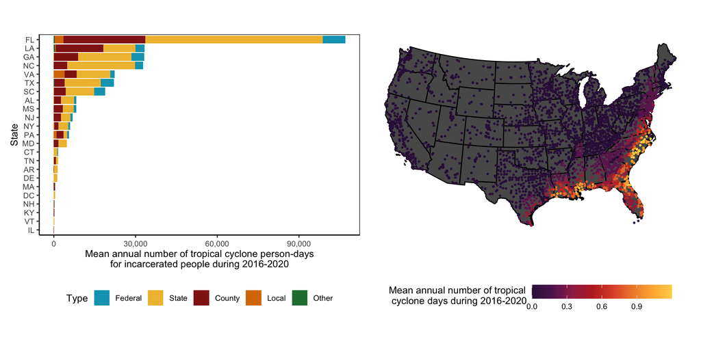

**Figure 1: Mean annual exposure during 2016-2020 to tropical cyclones in carceral facilities in the United States**

For each carceral facility (N = 4,078), metrics of tropical cyclone exposure is measured by: the number of person-days wind speeds exceeded 18 m/s for incarcerated people by state and carceral facility type (a) and the number of days wind speed exceeded 18 m/s for each carceral facility (b). State names are abbreviated with standard two-letter abbreviations.

## Hurricanes

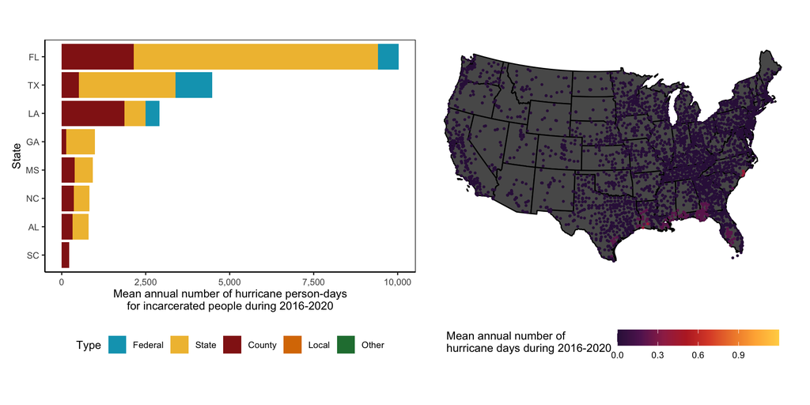

**Figure 2: Mean annual exposure during 2016-2020 to hurricanes in carceral facilities in the United States**

For each carceral facility (N = 4,078), metrics of hurricane exposure is measured by: the number of person-days wind speeds exceeded 33 m/s for incarcerated people by state and carceral facility type (a) and the number of days wind speed exceeded 33 m/s for each carceral facility (b). State names are abbreviated with standard two-letter abbreviations.

# Results: Wildfires

## Wildfires

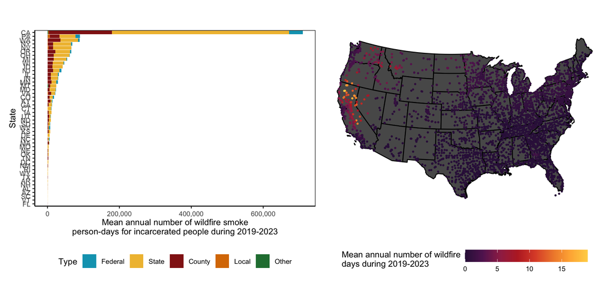

**Figure 3: Mean annual exposure during 2019-2023 to wildfires in carceral facilities in the United States**

For each carceral facility (N = 4,078), metrics of wildfire exposure is measured by: the number of person-days $PM_{2.5}$ smoke exceeded 35 $\mu g/m^3$ for incarcerated people by state and carceral facility type (a) and the number of days $PM_{2.5}$ smoke exceeded 35 $\mu g/m^3$ for each carceral facility (b). State names are abbreviated with standard two-letter abbreviations.

## Extreme Wildfires

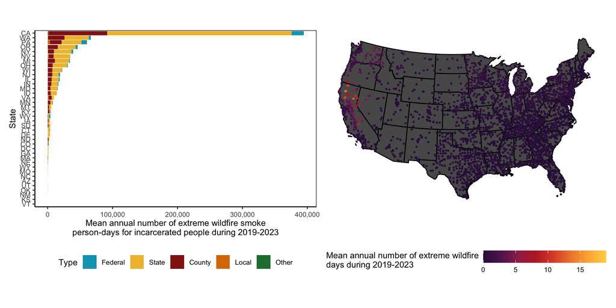

**Figure 4: Mean annual exposure during 2019-2023 to extreme wildfires in carceral facilities in the United States**

For each carceral facility (N = 4,078), metrics of extreme wildfire exposure is measured by: the number of person-days $PM_{2.5}$ smoke exceeded 55 $\mu g/m^3$ for incarcerated people by state and carceral facility type (a) and the number of days $PM_{2.5}$ smoke exceeded 55 $\mu g/m^3$ for each carceral facility (b). State names are abbreviated with standard two-letter abbreviations.

# Conclusion

Moving forward, we plan for our analysis to incorporate additional wildfire smoke exposure metrics by evaluating and exploring lower $PM_{2.5}$ thresholds and cumulative exposure metrics (e.g., smoke waves, defined as ≥2 consecutive days with $PM_{2.5}$ > 15 $\mu g/m^3$) to better characterize chronic exposure among incarcerated populations. We also will prioritize state and county correctional facilities, as it appears to experience the greatest climate hazard burden, while further evaluating federal facilities in California (wildfire smoke) and Florida, Texas, Georgia, and Louisiana (tropical cyclones). Our future analysis will utilize supplemental findings to inform evidence-based climate adaption policies, infrastructure improvements, and emergency preparedness to reduce climate-related health risks to advance environmental justice for incarcerated populations. It will also include additional figures with the results of characterizing the within-state exposure of incarcerated populations relative to the general population.

Division of Biostatistics

Department of Population Health Science

Bethany Akinola and Jordyn Begay, Weill Cornell Medicine Biostatistics Summer 2026 Internship